# 7.29作业杨佳琦

1.通过input输入一个字符，并判断它的类型，然后输出它是什么类型。 可以无限次输入，直至自己输入‘退出’才会结束。 例如：

- [1,24] --->print('您输入的是列表')
- Csd --->print('您输入的是字符串')

```python
while True:
    a=eval(input('please input:'))
    if a=='退出':
        break
    elif type(a)== int:
        print('您输入的是整数')
    elif type(a)== float:
        print('您输入的是复数')
    elif type(a)== list:
        print('您输入的是列表')
    elif type(a)== str:
        print('您输入的是字符串')
    else:
        print('您输入的是其它类型')
```

```
please input:'退出'
```

2.将字符串 去重并从小到大排序输出， 排序可用sorted()。 例如

- s = “ajldjlajfdljfddd”---->”adfjl”。

```python
s='ajldjlajfdljfddd'
b=''
for i in sorted(set(s)):
    b+=i
b
```

```
'adfjl'
```

3.根据num.txt，设计函数，计算每个小列表里面的平均人数。 例如：

- ['1000人以上'] ----> 1000
- ['50-150人'] ----> （150+50）/2 = 100,
- [''] ----> 0

最终结果保存在列表中，例如：[['50-150人'], [''],['1000人以上'] ] --> [100,0,1000,...]

```python
with open ('./data/num.txt','r')as f:
    num=f.read()
```

```python
a1=set(num.replace('"','').split(','))
a1
```

```
{" '[]'",
 " ['']",
 " ['1000-5000']",
 " ['1000-5000人']",
 " ['10000人以上']",
 " ['10000以上']",
 " ['150-500']",
 " ['150-500人']",
 " ['50-150']",
 " ['50-150人']",
 " ['500-1000']",
 " ['500-1000人']",
 " ['5000-10000']",
 " ['5000-10000人']",
 " ['5000-10000人']]",
 " ['少于50人']",
 "[['10000人以上']"}
```

```python
a=num.replace('"','').replace('[','').replace(']','').replace('人','').split(',')
```

```python
def pingjun(a):
    num_list=[]
    result_list=[]
    for i in a:
        if '以上' in i:
            num_list.append(i)
            num = int(i.replace('以上', ''))
            result_list.append(num)
        elif '少于' in i:
            num_list.append(i)
            n = int(i.replace('少于', ''))
            result_list.append(n)
        elif '-' in i:
            num1=i.split('-')[0]
            num2=i.split('-')[1]
            average=int(num1+num2)/2
            num_list.append(i)
            result_list.append(average)
        else:
            num_list.append(i)
            result_list.append(0)
    print(num_list)
    print(result_list)
```

```python
pingjun(a)
```

[output not shown]

4.定义了一个 Car 类，它有 brand、model 和 year 属性，表示汽车的品牌、型号和制造年份。还有 speed 属性表示当前车速。

- 类中定义三个方法：accelerate（加速）、brake（刹车）和 get_speed（获取速度）。
- accelerate可以输入加速参数increment表示加速了多少，输出经过加速后汽车的速度
- brake可以输入参数decrement表示减速了多少，输出减速后的汽车速度
- get_speed可以获取当前汽车的速度

```python
class Car:
    def __init__ (self,brand,model,year,speed):
        self.brand=brand
        self.model=model
        self.year=year
        self.speed=speed

    def accelerate(self,increment):
        print(f'加速了{increment}')
        self.speed=self.speed+increment
        return(f'经过加速后汽车的速度为:{self.speed}')

    def brake(self,decrement):
        print(f'减速了{decrement}')
        self.speed=self.speed-decrement
        return(f'减速后的汽车速度为:{self.speed}')

    def get_speed(self):
        return (f'当前汽车的速度为:{self.speed}')
```

```python
c=Car(brand='小鹏',model='ys',year='1999',speed=90)
print(c.accelerate(9))
print(c.brake(52))
print(c.get_speed())
```

```
加速了9
经过加速后汽车的速度为:99
减速了52
减速后的汽车速度为:47
当前汽车的速度为:47
```

5.内容判断

a = [1,2,3] 与 b = [3,2,1]，两个列表中的内容是一样的，怎么判断出来？

提示：集合

```python
a = [1,2,3]
b = [3,2,1]
if set(a)==set(b):
    print('内容一样')
else:
    print('内容不一样')
```

```
内容一样
```

6.（os、shutil模块的内容） 创建一个函数copy_directory，传入两个参数source_dir、destination_dir分别表示源文件夹和目标文件夹。 该函数作用是判断目标文件夹是否存在，如果不存在则新建，如果存在则把源文件夹下所有的内容复制到目标文件夹里面。

```python
import os,shutil
def copy_directory(source_dir,destination_dir):
    if os.path.exists(destination_dir)==False:
        os.mkdir(destination_dir)
    else:
        shutil.move(destination_dir,source_dir)
```

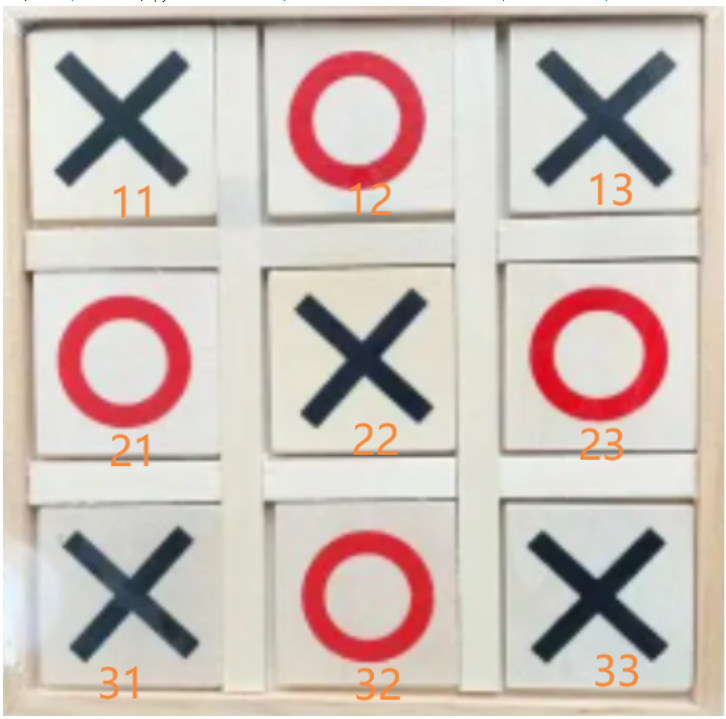

思路： A. 11，12，32等表示棋盘的位置，通过input提示X和O输入下棋的位置 B. 对输入的位置判断是否合法，只能是11，12，13，21，22，23，31，32，33几个位置，并且位置被占用之后不能重新下棋，例如：位置11被X占用之后，O不能再占用11。 C.每走一步判断谁输谁赢（三个棋连成线则赢，思考该怎么完成这个判断过程？），直到一方胜出或者走完9步为止则游戏结束。